# Exploratory Plots - Bulk RNAseq - Region: DLPFC

Juliana Beker Godoy UFPR Post graduate program in Bioinformatics Curitiba, Brazil

2025-02-11

```r
head(pheno_DLPFC)
```

```
##            projid study educ race msex spanish age_bl race7 apoe_genotype
## 00246264 00246264   MAP   16    1    0       2 89.990     1            33
## 00285563 00285563   MAP   12    1    0       2 84.704     1            33
## 00402800 00402800   MAP   16    1    0       2 78.691     1            34
## 00482428 00482428   MAP   12    1    0       2 81.380     1            23
## 00696418 00696418   MAP   14    1    0       2 83.765     1            33
## 01211411 01211411   ROS   12    1    1       2 85.248     1            NA
##          tomm40_hap age_death cogn_global_lv cogng_demog_slope cogng_path_slope
## 00246264          3   100.873       -0.23073           0.11803          0.07633
## 00285563          1    97.544       -2.24321          -0.04756         -0.00617
## 00402800          5    80.657       -2.21325          -0.11621         -0.03251
## 00482428          6    83.691       -0.07088           0.00330               NA
## 00696418          1    95.472       -0.07381           0.08212          0.07005
## 01211411         NA    85.550       -1.37814                NA               NA
##          tangles_sqrt  nft_sqrt amyloid_sqrt plaq_n_sqrt plaq_d_sqrt caa_4gp
```

[output cut: 27 more lines]

```r
table(pheno_DLPFC$cogdx_3grp)
```

```
##
##   0   1   2
## 397 286 526
```

```r
#######################
# cogdx_3grp code
# cogdx_3grp == 0 <- "NCI"
# cogdx_3grp == 1 <- "MCI"
# cogdx_3grp == 2 <- "AD"
#######################
```

# Demographics

## Donors

```
## [1] 1210
```

## Diagnosis

At the time of death, all available clinical data were reviewed by a neurologist with expertise in dementia, and a summary diagnostic opinion was rendered regarding the most likely clinical diagnosis at the time of death. Summary diagnoses were made blinded to all postmortem data. Case conferences including one or more neurologists and a neuropsychologist were used for consensus on selected cases.

NCI: Non cognitive impairment MCI: Mild cognitive impairment AD: Alzheimer’s Disease

Fonte: [Rush Alzheimer’s Disease Center (RADC)](https://www.radc.rush.edu/docs/var/detail.htm?category=Clinical+Diagnosis&subcategory=Final+consensus+diagnosis&variable=cogdx)

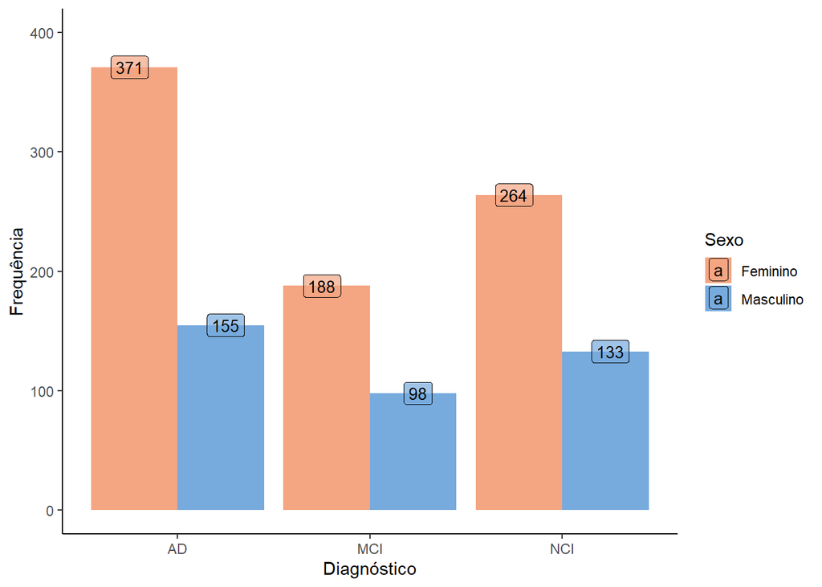

## Age at baseline assessment

The age at baseline assessment is calculated from subtracting the date of birth from the date of the baseline assessment and dividing by days per year (365.25).

This variable is related to the age at which the donor entered the cohort

```
## [1] "Media da idade de morte das mulheres: 81.2220461725395"
```

```
## [1] "Desvio padrao: 6.86620282321636"
```

```
## [1] "Media da idade de morte dos homens: 79.8994625322997"
```

```
## [1] "Desvio padrao: 7.06727119770302"
```

```
## [1] "Media da idade de entrada nos coortes: 80.7990380165289"
```

```
## [1] "Desvio padrao: 6.95564918691683"
```

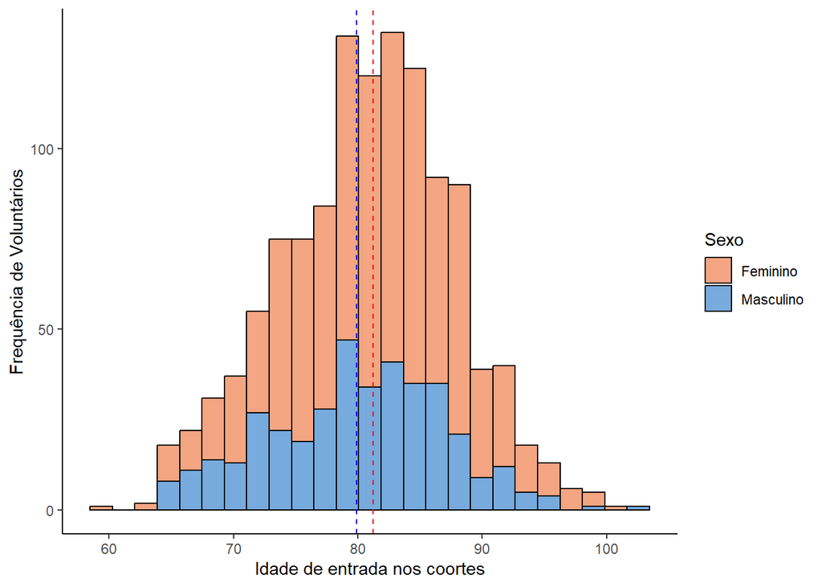

## Age by donors

Age of death is calculated from subtracting date of birth from date of death and dividing the difference by days per year (365.25).

For participants in autopsy cohorts, the exact date of death is known for most participants as it is the day an autopsy was performed. In all cohorts, in addition to annual evaluations, participants are also contacted quarterly to determine vital status and changes in health, and death is occasionally learned of during quarterly contacts.

```
## [1] "Media da idade de morte das mulheres: 90.2314507897934"
```

```
## [1] "Desvio padrao: 6.60777105892002"
```

```
## [1] "Media da idade de morte dos homens: 87.9715426356589"
```

```
## [1] "Desvio padrao: 6.38816329552368"
```

```
## [1] "Media da idade de morte geral: 89.5086537190083"
```

```
## [1] "Desvio padrao: 6.62021576804519"
```

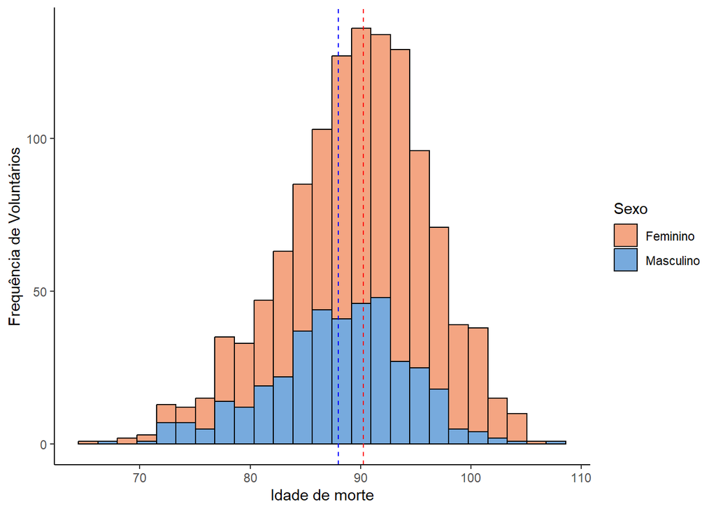

## Years of education (box plot)

The years of education variable is based on the number of years of regular school reported at baseline cognitive testing.

```
## [1] "Media de anos de educação formal das mulheres: 15.7691373025516"
```

```
## [1] "Desvio padrao: 3.25070385181732"
```

```
## [1] "Media de anos de educação formal dos homens: 17.0723514211886"
```

```
## [1] "Desvio padrao: 3.8976458153724"
```

```
## [1] "Media de anos de educação formal geral: 16.1859504132231"
```

```
## [1] "Desvio padrao: 3.52201643934664"
```

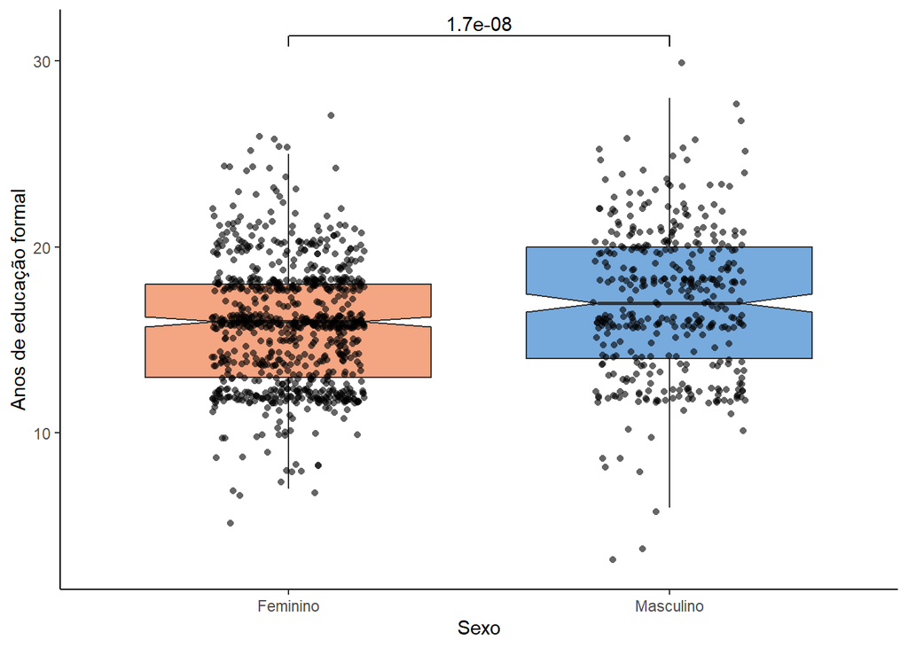

## Years of education compared with cognitive global variable

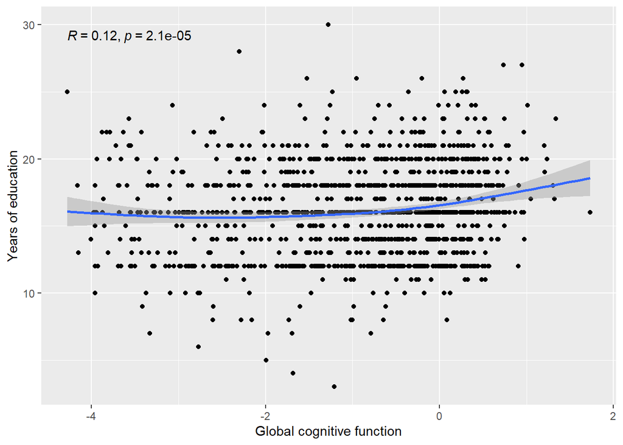

## Donors by cohort

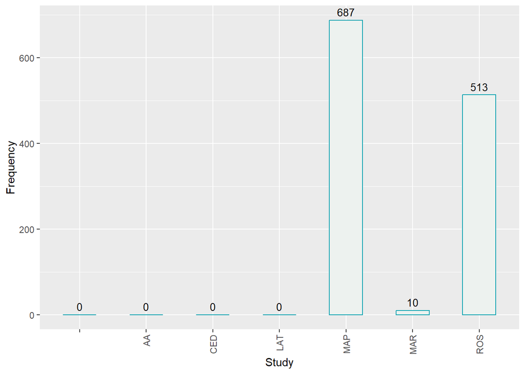

## Race

Race is based on self-report at baseline using the following question:

What is your race?

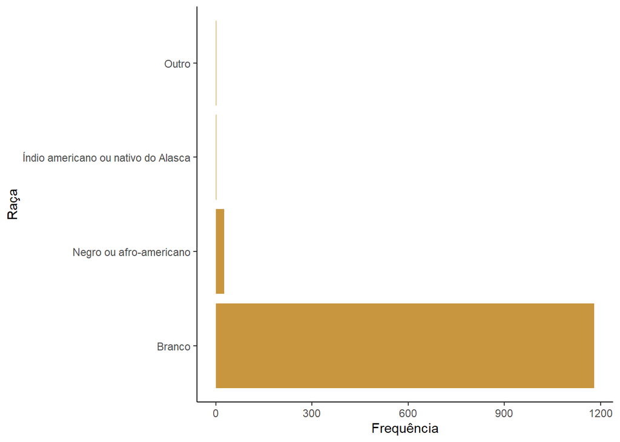

## APOE frequency

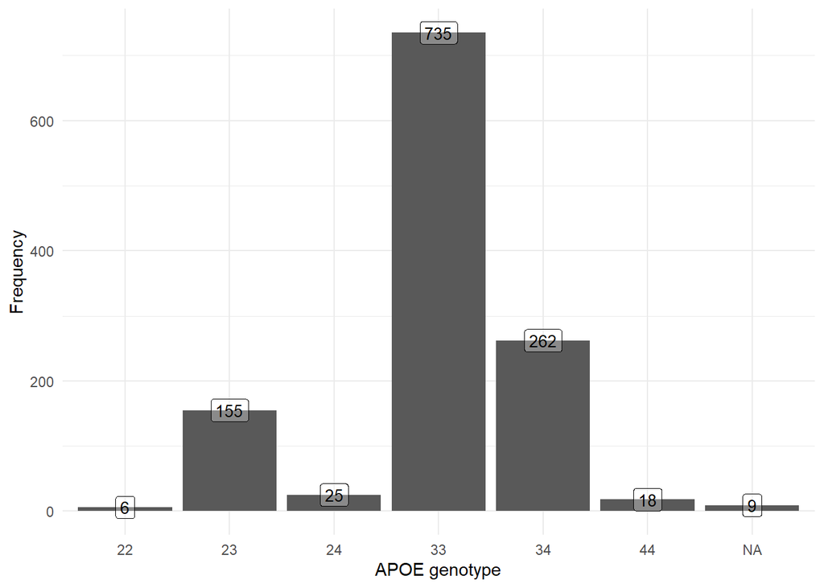

## APOE genotype by diagnosis

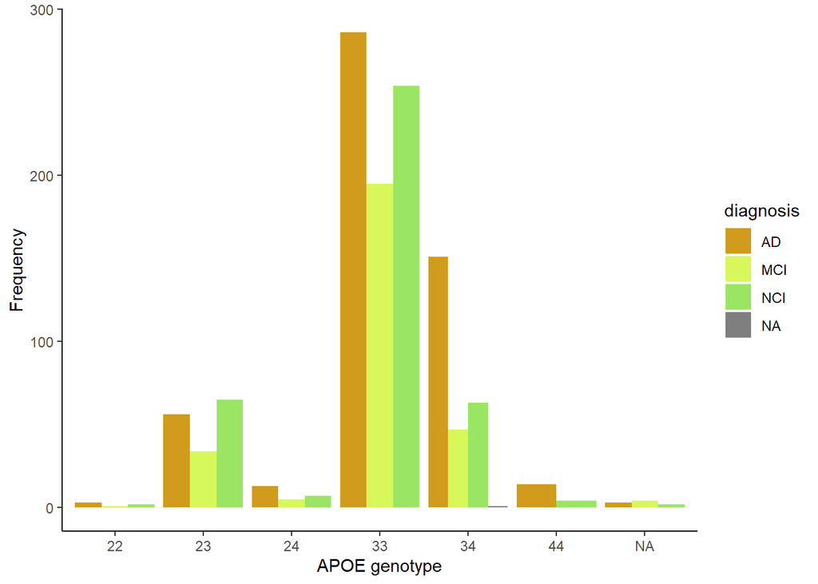

## TOMM40 genotype frequency

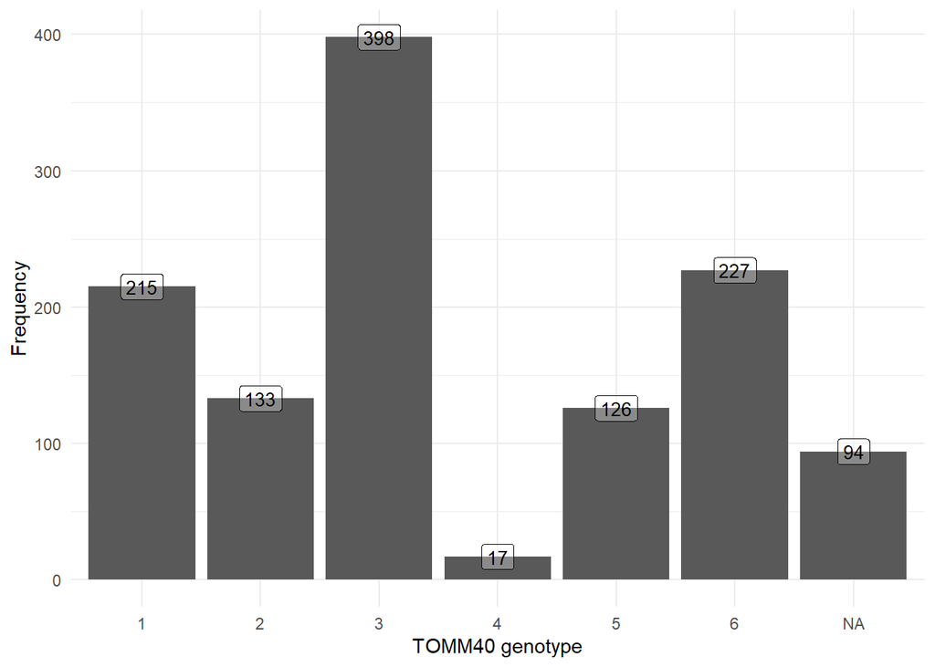

## TOMM40 genotype by diagnosis

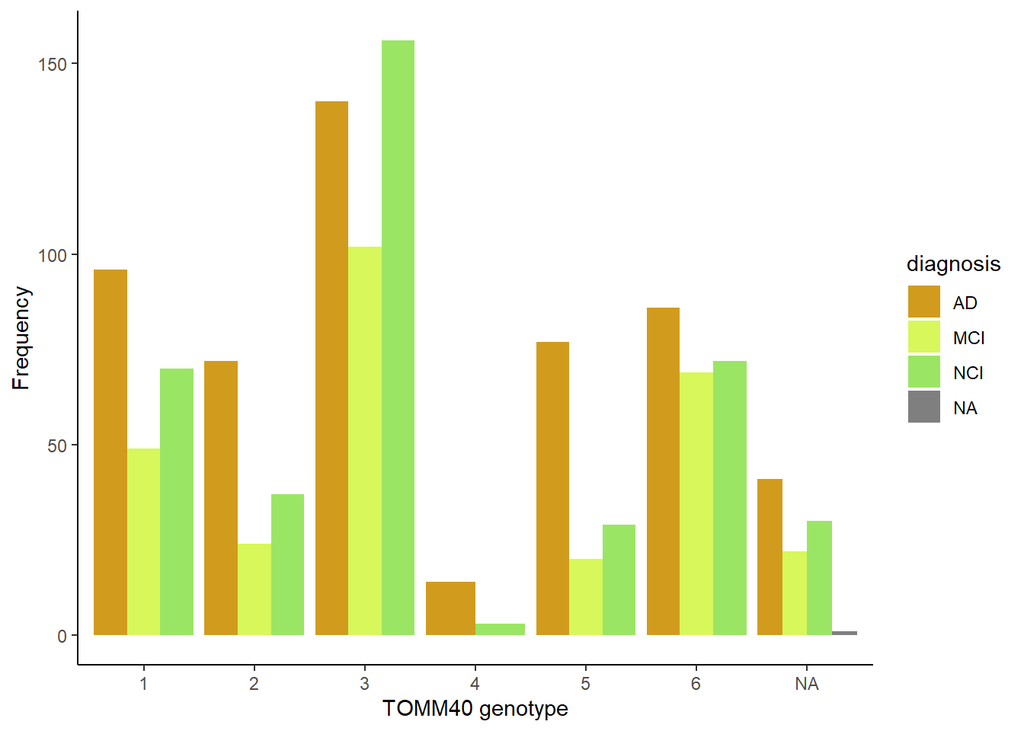